# TidyTuesday Analysis: Chocolate Ratings

#The map

A map is the most immediate way to communicate where the problem is actually located

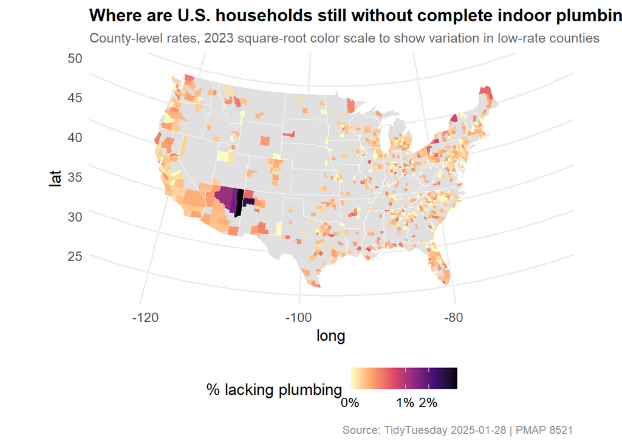

```r
# Drop geometry from the sf object so we can join to a pre-built county map
water_df <- water_clean |>
  st_drop_geometry() |>
  mutate(fips = geoid)

# Use map_data for a lightweight base map (no heavy shapefile needed)
counties_map <- map_data("county")

# FIPS lookup to join on state + county name
data(county.fips, package = "maps")
county_fips_clean <- county.fips |>
  as_tibble() |>
  mutate(
    fips      = str_pad(as.character(fips), 5, pad = "0"),
    polyname  = polyname
  )

water_map_df <- water_df |>
  left_join(county_fips_clean, by = "fips") |>
  separate(polyname, into = c("region_map", "subregion"), sep = ",", extra = "drop") |>
  right_join(counties_map, by = c("region_map" = "region", "subregion" = "subregion"))

ggplot(water_map_df, aes(x = long, y = lat, group = group,
                          fill = percent_lacking_plumbing)) +
  geom_polygon(color = NA) +
  geom_polygon(
    data  = map_data("state"),
    aes(x = long, y = lat, group = group),
    fill  = NA, color = "white", linewidth = 0.3,
    inherit.aes = FALSE
  ) +
  coord_map("albers", lat0 = 29.5, lat1 = 45.5) +
  scale_fill_viridis_c(
    option   = "magma",
    direction = -1,
    na.value = "grey88",
    labels   = label_percent(scale = 1),
    breaks   = c(0, 1, 2, 5, 10, 20),
    trans    = "sqrt",
    name     = "% lacking plumbing"
  ) +
  labs(
    title    = "Where are U.S. households still without complete indoor plumbing?",
    subtitle = "County-level rates, 2023 square-root color scale to show variation in low-rate counties",
    caption  = "Source: TidyTuesday 2025-01-28 | PMAP 8521"
  )
```

# Naive vs. adjusted regression

Now for the modeling. Following the DAG, I run two regressions:

- **Naive**: just regress the plumbing rate on log population, ignoring the backdoors.
- **Adjusted**: add region fixed effects to close the Region backdoor path. This is the adjustment-based identification strategy from week 7 of the course.

```r
# Naive model — ignores regional confounding
model_naive <- lm_robust(
  percent_lacking_plumbing ~ log_pop,
  data = water_clean)
model_naive
```

```
##                Estimate  Std. Error   t value     Pr(>|t|)    CI Lower
## (Intercept)  0.46014543 0.105539459  4.359937 1.463788e-05  0.25299090
## log_pop     -0.02988451 0.008127945 -3.676761 2.513547e-04 -0.04583817
##                CI Upper  DF
## (Intercept)  0.66729996 833
## log_pop     -0.01393085 833
```

```r
# Adjusted model — region fixed effects close the regional backdoor
model_adjusted <- lm_robust(
  percent_lacking_plumbing ~ log_pop + region,
  data = water_clean)
model_adjusted
```

```
##                  Estimate Std. Error   t value     Pr(>|t|)     CI Lower
## (Intercept)    0.54136170 0.12789835  4.232750 2.566106e-05  0.290319468
## log_pop       -0.03645625 0.01012895 -3.599213 3.381017e-04 -0.056337626
## regionMidwest -0.03235322 0.01240224 -2.608659 9.253287e-03 -0.056696661
## regionSouth   -0.01543793 0.01146431 -1.346607 1.784744e-01 -0.037940381
## regionWest     0.08174787 0.03810702  2.145218 3.222501e-02  0.006950404
##                   CI Upper  DF
## (Intercept)    0.792403933 830
## log_pop       -0.016574884 830
## regionMidwest -0.008009769 830
## regionSouth    0.007064529 830
## regionWest     0.156545341 830
```

```r
# Population-quartile model — non-parametric version of the same question
model_quartile <- lm_robust(
  percent_lacking_plumbing ~ pop_quartile_label + region,
  data = water_clean)
model_quartile
```

```
##                                  Estimate Std. Error   t value     Pr(>|t|)
## (Intercept)                    0.14131459 0.02383721  5.928321 4.489863e-09
## pop_quartile_label25–50%      -0.03249231 0.02645483 -1.228218 2.197141e-01
## pop_quartile_label50–75%      -0.06118642 0.02491102 -2.456199 1.424587e-02
## pop_quartile_labelLargest 25% -0.08941856 0.02746446 -3.255791 1.176718e-03
## regionMidwest                 -0.02958335 0.01194993 -2.475608 1.349999e-02
## regionSouth                   -0.01408586 0.01116941 -1.261110 2.076244e-01
## regionWest                     0.07992975 0.03748661  2.132221 3.328237e-02
##                                   CI Lower     CI Upper  DF
## (Intercept)                    0.094526137  0.188103051 828
## pop_quartile_label25–50%      -0.084418737  0.019434117 828
## pop_quartile_label50–75%      -0.110082587 -0.012290250 828
## pop_quartile_labelLargest 25% -0.143326715 -0.035510403 828
## regionMidwest                 -0.053039078 -0.006127623 828
## regionSouth                   -0.036009550  0.007837833 828
## regionWest                     0.006349782  0.153509718 828
```

```r
modelsummary(
  list(
    "Naive"    = model_naive,
    "Adjusted" = model_adjusted
  ),
  stars   = TRUE,
  gof_map = c("nobs", "r.squared"),
  coef_rename = c(
    "(Intercept)"                     = "Intercept",
    "log_pop"                         = "Log county population",
    "regionMidwest"                   = "Region: Midwest",
    "regionSouth"                     = "Region: South",
    "regionWest"                      = "Region: West"
  ),
  title = "Naive vs. region-adjusted estimates: population and water insecurity"
)
```

|  | Naive | Adjusted |
| --- | --- | --- |
| Intercept | 0.460*** | 0.541*** |
|  | (0.106) | (0.128) |
| Log county population | -0.030*** | -0.036*** |
|  | (0.008) | (0.010) |
| Region: Midwest |  | -0.032** |
|  |  | (0.012) |
| Region: South |  | -0.015 |
|  |  | (0.011) |
| Region: West |  | 0.082* |
|  |  | (0.038) |
| Num.Obs. | 835 | 835 |
| R2 | 0.018 | 0.053 |

+ p < 0.1, * p < 0.05, ** p < 0.01, *** p < 0.001

The naive model says that larger counties have lower plumbing insecurity rates which is technically true as a raw correlation. But once we control for region (closing that backdoor path), the estimate on log population changes. The regional fixed effects absorb the fact that larger counties also tend to be in different parts of the country with different baseline infrastructure. What’s left is closer to a within region comparison: among counties in the same part of the country, do bigger ones have lower rates?